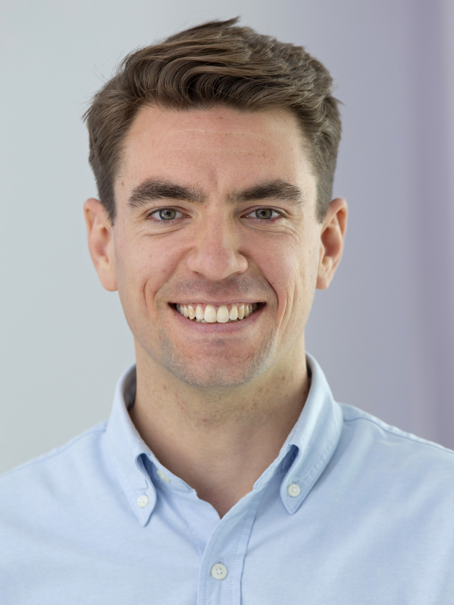

# Anton (Anjo) Peez

## **Hi!**

I am a political scientist, Postdoctoral Researcher at the [University of Frankfurt](https://www.fb03.uni-frankfurt.de/174310675/Dr__Anton_Peez), and Associate Fellow at [Peace Research Institute Frankfurt (PRIF)](https://www.prif.org/en/).

Most recently, I’ve had research stays at [UC Berkeley’s Political Science Department](https://polisci.berkeley.edu/) (01–08/2023); [Nuffield College, University of Oxford](https://www.nuffield.ox.ac.uk/) (10–12/2022); and at the [Global Governance Research Unit](https://www.wzb.eu/en/research/international-politics-and-law/global-governance) at WZB Berlin Social Science Center (12/2021–03/2022).

You can find my current CV [here](https://www.dropbox.com/scl/fi/0nyo0i1f1cpdtrnnd440l/CV_AP_public_2026_09b.pdf?rlkey=acb324o8kzb7qcijzdpbhozoi&st=o847yzzk&dl=0).

## **Research interests**

I mainly study international politics and global order, including peace and conflict, economic sanctions, multilateralism, and public and elite opinion on international affairs. I use causal inference techniques for observational data as well as experimental approaches, and have experience in archival and qualitative case study research.

## **Some recent publications**

Full publication records are available in my CV (above) and on [Google Scholar](https://scholar.google.com/citations?user=zq33MJAAAAAJ&hl=en).

Peez, Anton/Bethke, Felix S. (forthcoming): [How Citizens Update their Preferences on Foreign Policy: Experimental Evidence on Western Sanctions](https://osf.io/preprints/osf/s87fd). In: *Journal of Peace Research.*

Grauvogel, Julia/Attia, Hana/Peez, Anton/Brettfeld, Katrin/Richter, Thomas/Wetzels, Peter (2026): [Public Opinion on Sanctions Compliance and Evasion: Experimental Evidence from the 2022–23 Russia Sanctions](https://doi.org/10.1177/07388942261458232). In: *Conflict Management and Peace Science.*

Peez, Anton/Scherzinger, Johannes (2026): [Using LLMs for Measurement in Diplomatic Speeches: The Evolving Politics of UN Sanctions in Security Council Debates](https://doi.org/10.1007/s11558-026-09620-y). 🔓 In: *The Review of International Organizations.* [[Replication materials](https://doi.org/10.7910/DVN/YZLYUN).]

Peez, Anton (2025): [Re-examining the Effects of Western Sanctions on Democracy and Human Rights in the 21<sup>st</sup> Century](https://doi.org/10.1017/psrm.2025.10058). 🔓 In: *Political Science Research and Methods.* [[Replication materials](https://doi.org/10.7910/DVN/8D9IK3).]

Peez, Anton/Bethke, Felix S. (2025): [Does Public Opinion on Foreign Policy Affect Elite Preferences? Evidence from the 2022 US Sanctions against Russia](https://academic.oup.com/isq/article/69/1/sqae145/7929343). 🔓 In: *International Studies Quarterly* 69: 1, 1–11. [[Replication materials](https://doi.org/10.7910/DVN/P8KSED).]

Zimmermann, Lisbeth/Deitelhoff, Nicole/Lesch, Max/Arcudi, Antonio/Peez, Anton (2023): [*International Norm Disputes. The Link between Contestation and Norm Robustness*](https://global.oup.com/academic/product/international-norm-disputes-9780198873235). Oxford, UK: Oxford University Press. [[Replication materials](https://doi.org/10.7910/DVN/6VHFZK); Honorable Mention/Runner Up, 2025 ISA International Law Section Book Award; reviewed in [*International Affairs*](https://doi.org/10.1093/ia/iiae244).]

## **Working papers and pre-prints**

De Juan, Alexander/Peez, Anton/Riaz, Sascha/Voß, Julian: [Revisiting History, Reshaping Memory: The Effects of Confronting Ingroup Atrocities](https://osf.io/preprints/osf/esh6f). *Conditionally accepted, American Journal of Political Science.*

Peez, Anton/Bethke, Felix S.: [Do Geopolitical Crisis Events Affect Public Opinion on Foreign Policy? Evidence from the 2022 Russian Invasion of Ukraine](https://osf.io/preprints/osf/huady). *Conditionally accepted, International Studies Quarterly.*

Bethke, Felix S./Bunde, Tobias/Driedger, Jonas J./Peez, Anton: [Preferences for Peace between Ukraine and Russia: Experimental Evidence from Transatlantic Elites](https://osf.io/preprints/osf/zpm8r). *R&R, Journal of Global Security Studies.*

Langlitz, Jan/Peez, Anton: [Who Changes Their Mind After Dramatic Diplomatic Events? Public Opinion and the Trump/Zelenskyy Oval Office Meeting](https://osf.io/preprints/socarxiv/zdxcg_v1). *Under review.*

Peez, Anton/Bethke, Felix S.: [Elite-Public Gaps on Salient Foreign Policy Issues: Experimental Evidence from the 2022/23 US Sanctions on Russia](https://osf.io/preprints/socarxiv/uzprs_v1). *Under review.*

Attia, Hana/Peez, Anton: [Equals or Outcasts? Public Opinion on Reconciliation with Sanctioned States](https://osf.io/preprints/osf/4hn2b).

## **Selected policy writing and outreach**

Peez, Anton (2026): [*The Growing Transatlantic Sanctions Divide*](https://doi.org/10.82088/IAIbrief2645). 🔓 IAI Policy Brief 26/45. Rome, Italy: Istituto Affari Internazionali.

Portela, Clara/Tilahun, Nathanael/Peez, Anton (2025): *The Effectiveness of the EU Global Human Rights Sanctions Regime*. 🔓 Study requested by the European Parliament’s Subcommittee on Human Rights.

Brockmeier-Large, Sarah & Peez, Anton (2024/2021): [*German Foreign Policy and the Rwandan Genocide*](https://www.boell.de/de/2021/03/29/akteneinsichten-die-deutsche-aussenpolitik-und-der-voelkermord-in-ruanda). 🔓 Berlin: Heinrich Böll Foundation. [English (2024)](https://osf.io/preprints/socarxiv/9ks5f), [German (2021)](https://osf.io/preprints/socarxiv/wd27k). Selected media coverage: [Die ZEIT](https://www.zeit.de/2024/15/voelkermord-ruanda-hutu-gruppen-deutschland-verantwortung/komplettansicht), ARD ([1](https://www.ardaudiothek.de/episode/ard-radiofeature/toedliches-schweigen-doku-ueber-die-rolle-deutschlands-und-frankreichs-beim-genozid-in-ruanda/ard/13280573/), [2](https://www.ardaudiothek.de/episode/ard-radiofeature/toedliches-schweigen-die-journalistin-sabine-wachs-im-gespraech/ard/13280509/)), [Tagesschau/ARD](https://www.tagesschau.de/inland/innenpolitik/voelkermord-ruanda-100.html).

Co-coordinator: Abb, Pascal/Attia, Hana/Brzoska, Michael/Daase, Christopher/Deitelhoff, Nicole/Grauvogel, Julia/Peez, Anton (2022): [Only a Means to an End: The Conditions for Sanctions Success](https://www.friedensgutachten.de/user/pages/04.archiv/2022/02.ausgabe/Friedensgutachten%202022%20E-Book.pdf). 🔓 In: *Friedensgutachten 2022*. Chapter 4, 110–131. [in German – the annual joint yearbook of German’s largest peace and conflict studies institutes.] Selected media coverage: [Tagesschau](https://www.tagesschau.de/inland/innenpolitik/friedensforschung-ukraine-101.html), [Die ZEIT/DPA](https://www.zeit.de/news/2022-06/21/forscher-regeln-fuer-ruecknahme-von-sanktionen-kommunizieren), [FAZ](https://www.faz.net/aktuell/politik/inland/ukraine-friedensgutachten-warnt-vor-nuklearer-eskalation-18118354.html).

## **Teaching**

I teach advanced undergraduate/graduate courses on economic sanctions, public opinion, world order, and social science research design.

## **Other interests, projects, and media**

I offer scholarly opinions based on my research, including in/on [ARD](https://www.ardaudiothek.de/episode/ard-radiofeature/toedliches-schweigen-doku-ueber-die-rolle-deutschlands-und-frankreichs-beim-genozid-in-ruanda/ard/13280573/), [ZDF heute](https://www.zdf.de/nachrichten/politik/sanktionen-wirkung-konflikt-ukraine-russland-100.html), HR2 Kultur ([1](https://podcasts.apple.com/de/podcast/swift-die-finanzwaffe/id91697773?i=1000548503123), [2](https://podcasts.apple.com/de/podcast/er-hat-es-getan-putins-angriff-und-die-folgen/id91697773?i=1000552140321)), [HR Info](https://podcasts.apple.com/de/podcast/kampf-dem-schwarzmarkt-entwicklungsarbeit-gegen-den/id1542750625?i=1000520030876), N-TV ([1](https://podcasts.apple.com/de/podcast/iran-und-russland-sanktionen-abschreckung-oder-l%C3%A4ngst/id1641884699?i=1000653524202), [2](https://www.n-tv.de/wirtschaft/Sind-Sanktionen-Abschreckung-oder-laengst-Alltag-article24898516.html)), and elsewhere. I also occasionally moderate and participate in public events and panels, including at the [Berlin International Literature Festival (ilb)](https://www.youtube.com/watch?v=uj-lX8iJoXk) or with the [Heinrich Böll Foundation](https://www.youtube.com/watch?v=oZVxgXwH8_g).

A while back, I researched, visualized, and edited data-driven journalism at [*Einfacher Dienst*](https://einfacherdienst.de/) as a co-founder, mostly focusing on German domestic politics. Our results and work were featured in [FAZ](https://www.faz.net/aktuell/feuilleton/pop/warum-deutschsprachige-musik-ploetzlich-so-erfolgreich-ist-16126000.html), [taz](https://taz.de/Wie-die-AfD-mit-kritischen-Fragen-umgeht/!5527392/), [Deutschlandfunk Nova](https://www.deutschlandfunknova.de/beitrag/sachsen-kritik-der-berichterstattung-ueber-dresden-und-chemnitz), the [ZDF Heute-Show](https://www.youtube.com/watch?v=T-D6lN7F9io), and [VICE Germany](https://www.vice.com/de/article/bvg55v/die-partei-genossen-sollen-mitglieder-sexuell-belastigt-haben-sexismus-antidiskriminierung), among other outlets.

In the past, I have worked for or interned at the German Bundestag, Goethe-Institut Kigali (Rwanda), the Federal Statistical Office, and the Federal Institute for Population Research.

Outside of work, I enjoy running, collage, and following baseball.

Website made with [postcards](https://cran.r-project.org/web/packages/postcards/) in [RMarkdown](https://rmarkdown.rstudio.com/).